# Proteomic Subtypes Predicted through DEPs Calculated by The Stromal Scores and The Immune Scores

2019250101 Jo yeongseo

2021 12 11

# 1. Introduction

Our research paper (Chen et al, 2020) studied unique drivers, biomarkers, and mutagenesis through multiomics data of non-smokers lung cancer patients in Taiwan. In addition, through proteome-based classification, they found that some patients in IA and IB stages were divided into ‘late-like’ stages and had clinical implications.

Meanwhile, tumor staging, which is currently being used, is limited in providing cancer prognosis information and cannot predict responses to treatment, so attempts are being made to predict prognosis using other indicators. In some papers, they analyzed stromal scores, immune scores, and life information, and studied how the life can be predicted with the corresponding scores. The stromal and immune scores of tumor and normal were divided into high and low groups, respectively, and DEGs with significant differences between the two groups were selected, and life expectancy was predicted using them.

There is no lifetime information in our dataset, so I was wondering what other information could be grasped through the stromal scores and the immune scores. Now, let’s divide the stromal and immune scores of tumor and normal into high and low groups, respectively, and select DEPs with significant differences between the two groups, and find out information that can be predicted by using them.

- DEGs: Differentially Expressed Genes.
- DEPs: Differentially Expressed Proteins.
- stromal score: quantifying the density and location of stromal cells.
- immune score: quantifying the density and location of immune cells.

# 2. Results

## 2.1. Unboxing and adjusting the data

```r
library(readxl)
library(ggplot2)
library(dplyr)


# S1A table: personal information
S1A <- read_excel("C:/Users/ysjo/Documents/Biostat/bsms222_101_jo/TW data/1-s2.0-S0092867420307431-mmc1.xlsx",
                  sheet = 2)


# S7C table: stromal and immune score of tumor and normal
s7c <- read_excel("C:/Users/ysjo/Documents/Biostat/bsms222_101_jo/TW data/1-s2.0-S0092867420307431-mmc7.xlsx",
                  sheet = 4)

## split ID and tissue type
library(splitstackshape)
s7c <- cSplit(s7c, "Patient.tissue sample", ".")
names(s7c)[5] <- 'ID'
names(s7c)[6] <- 'tissue_type'

## one line for each patient
s7c_N <- s7c %>%
  filter(tissue_type == 'N')
s7c_T <- s7c %>%
  filter(tissue_type == 'T')
stromal_immune_score <- merge(s7c_N %>% select(!tissue_type),
                              s7c_T %>% select(!tissue_type),
                              by = 'ID', all = TRUE)
names(stromal_immune_score)[2:5] <- gsub('x', 'N', names(stromal_immune_score)[2:5])
names(stromal_immune_score)[6:9] <- gsub('y', 'T', names(stromal_immune_score)[6:9])
names(stromal_immune_score)[9] <- "Tumor Purity.T"  # change 'Tumor PuritT.T' into 'Tumor Purity.T'


N_stromal_median <- stromal_immune_score %>%
  pull(`Stromal Score.N`) %>%
  median()
N_immune_median <- stromal_immune_score %>%
  pull(`Immune Score.N`) %>%
  median()
T_stromal_median <- stromal_immune_score %>%
  pull(`Stromal Score.T`) %>%
  median()
T_immune_median <- stromal_immune_score %>%
  pull(`Immune Score.T`) %>%
  median()

# stromal score/high or low + immune score/high or low + personal information
stromal_immune_data <- merge(stromal_immune_score %>%
                mutate(Stromal.N.high = ifelse(`Stromal Score.N` > N_stromal_median, 'stromal.N.high', 'stromal.N.low')) %>%
                mutate(Immune.N.high = ifelse(`Immune Score.N` > N_immune_median, 'immune.N.high', 'immune.N.low')) %>%
                mutate(Stromal.T.high = ifelse(`Stromal Score.T` > T_stromal_median, 'stromal.T.high', 'stromal.T.low')) %>%
                mutate(Immune.T.high = ifelse(`Immune Score.T` > T_immune_median, 'immune.T.high', 'immune.T.low')),
              S1A, key = 'ID')


# S1E table: proteome log2TN
S1E <- read_excel("C:/Users/ysjo/Documents/Biostat/bsms222_101_jo/TW data/1-s2.0-S0092867420307431-mmc1.xlsx",
                  sheet = 6, na = 'NA')
S1E <- t(S1E)
S1E <- cbind(ID = rownames(S1E), S1E)
rownames(S1E) <- 1:nrow(S1E)
colnames(S1E) <- S1E[2,]
colnames(S1E)[1] <- 'ID'
S1E <- S1E[-c(1,2,3),]

# proteome log2TN + stromal score/high or low + immune score/high or low + personal information
gene_score_data <- merge(S1E, stromal_immune_data, by = 'ID')
gene_score_data <- gene_score_data[!is.na(colnames(gene_score_data))] # remove null colnames column

gene_score_data <- gene_score_data %>%
    select_if(~ !any(is.na(.)))  # remove genes which have NAs
gene_score_data[2:7631] <- lapply(gene_score_data[2:7631], as.numeric) # revised line through peer review
# the reason of [2:7631]: [1] is patient's ID, [7632:7651] are information about patients, and the rest is proteome log2T/N.


# S6A table: additional information
s6a <- read_excel("C:/Users/ysjo/Documents/Biostat/bsms222_101_jo/TW data/1-s2.0-S0092867420307431-mmc6.xlsx",
                  sheet = 2)
S6A <- t(s6a)
colnames(S6A) <- S6A[1,]
S6A <- S6A[-c(1,2,3,4,5),]
S6A <- cbind(ID = rownames(S6A), S6A)
rownames(S6A) <- 1:nrow(S6A)
information <- S6A[,1:24]
```

In the above code, I found a critical mistake thanks to peer review. By revising `gene_score_data[2:7631] <- lapply(gene_score_data, as.numeric)` to `gene_score_data[2:7631] <- lapply(gene_score_data[2:7631], as.numeric)`, proper data could be utilized.

## 2.2. Find out differentially expressed proteins (DEPs)

There are four groups of the scores - stromal score of normal, immune score of normal, stromal score of tumor, and immune score of tumor. Based on the median of each group, it was divided into high subgroup and low subgroup. In order to find DEPs with significant p-values (p < 0.05) between subgroups in each group, for-loop was created to proceed with the Wilcox test and filter with p < 0.05. 1200 DEPs were found in Stromal Normal, 836 in Immune Normal, 906 in Stromal Tumor, and 412 in Immune Tumor.

```r
# stromal.N.p-value.significant
library(ggpubr)
Stromal.N.p <- data.frame(Characters=character(),
                Characters=character(),
                Characters=character(),
                p=numeric(),
                p.adj=numeric(),
                p.format=numeric(),
                p.signif=character(),
                Characters=character(),
                stringsAsFactors=FALSE)
for (i in 2:7631){
  new <- gene_score_data[,c(i,7640)]
  colnames(new)<-c("interest","Stromal.N.high")
  Stromal.N.p <- rbind(Stromal.N.p,
                       compare_means(interest~Stromal.N.high, data = new, method = "wilcox.test",
                                     paired = FALSE, group.by = NULL, ref.group = NULL))
}
Stromal.N.p <- cbind(names(gene_score_data)[2:7631], Stromal.N.p)
names(Stromal.N.p)[1] <- 'gene.of.proteome'


Stromal.N.p.signif <- Stromal.N.p %>%
  mutate(p.format.stromal.N = p.format,
         p.signif.stromal.N = p.signif) %>%
  select(gene.of.proteome, p.format.stromal.N, p.signif.stromal.N) %>%
  filter(p.format.stromal.N < 0.05)


# immune.N.p-value.significant
Immune.N.p <- data.frame(Characters=character(),
                Characters=character(),
                Characters=character(),
                p=numeric(),
                p.adj=numeric(),
                p.format=numeric(),
                p.signif=character(),
                Characters=character(),
                stringsAsFactors=FALSE)
for (i in 2:7631){
  new <- gene_score_data[,c(i,7641)]
  colnames(new)<-c("interest","Immune.N.high")
  Immune.N.p <- rbind(Immune.N.p,
                       compare_means(interest~Immune.N.high, data = new, method = "wilcox.test",
                                     paired = FALSE, group.by = NULL, ref.group = NULL))
}
Immune.N.p <- cbind(names(gene_score_data)[2:7631], Immune.N.p)
names(Immune.N.p)[1] <- 'gene.of.proteome'

Immune.N.p.signif <- Immune.N.p %>%
  mutate(p.format.immune.N = p.format,
         p.signif.immune.N = p.signif) %>%
  select(gene.of.proteome, p.format.immune.N, p.signif.immune.N) %>%
  filter(p.format.immune.N < 0.05)


# stromal.T.p-value.significant
Stromal.T.p <- data.frame(Characters=character(),
                Characters=character(),
                Characters=character(),
                p=numeric(),
                p.adj=numeric(),
                p.format=numeric(),
                p.signif=character(),
                Characters=character(),
                stringsAsFactors=FALSE)
for (i in 2:7631){
  new <- gene_score_data[,c(i,7642)]
  colnames(new)<-c("interest","Stromal.T.high")
  Stromal.T.p <- rbind(Stromal.T.p,
                       compare_means(interest~Stromal.T.high, data = new, method = "wilcox.test",
                                     paired = FALSE, group.by = NULL, ref.group = NULL))
}
Stromal.T.p <- cbind(names(gene_score_data)[2:7631], Stromal.T.p)
names(Stromal.T.p)[1] <- 'gene.of.proteome'


Stromal.T.p.signif <- Stromal.T.p %>%
  mutate(p.format.stromal.T = p.format,
         p.signif.stromal.T = p.signif) %>%
  select(gene.of.proteome, p.format.stromal.T, p.signif.stromal.T) %>%
  filter(p.format.stromal.T < 0.05)



# immune.T.p-value.significant
Immune.T.p <- data.frame(Characters=character(),
                Characters=character(),
                Characters=character(),
                p=numeric(),
                p.adj=numeric(),
                p.format=numeric(),
                p.signif=character(),
                Characters=character(),
                stringsAsFactors=FALSE)
for (i in 2:7631){
  new <- gene_score_data[,c(i,7643)]
  colnames(new)<-c("interest","Immune.T.high")
  Immune.T.p <- rbind(Immune.T.p,
                       compare_means(interest~Immune.T.high, data = new, method = "wilcox.test",
                                     paired = FALSE, group.by = NULL, ref.group = NULL))
}
Immune.T.p <- cbind(names(gene_score_data)[2:7631], Immune.T.p)
names(Immune.T.p)[1] <- 'gene.of.proteome'

Immune.T.p.signif <- Immune.T.p %>%
  mutate(p.format.immune.T = p.format,
         p.signif.immune.T = p.signif) %>%
  select(gene.of.proteome, p.format.immune.T, p.signif.immune.T) %>%
  filter(p.format.immune.T < 0.05)
```

```r
# Differentially Expressed Proteins
merge.stromal <- merge(Stromal.N.p.signif, Stromal.T.p.signif, by = 'gene.of.proteome')
merge.immune <- merge(Immune.N.p.signif, Immune.T.p.signif, by = 'gene.of.proteome')
merge.final <- merge(merge.stromal, merge.immune, by = 'gene.of.proteome')
DEPs <- merge.final %>% pull(gene.of.proteome)
DEPs
```

```
## [1] "APH1B"  "DOCK11" "NENF"
```

The `merge` function was used to find the DEPs that the four groups have in common, and as a result, three DEPs were found - **APH1B, DOCK11, and NENF**. In fact, these are the name of the genes, but I will use these like the name of the proteins.

Let’s find out their roles through ‘www.uniprot.org’.

- APH1B: Probable subunit of the gamma-secretase complex, an endoprotease complex that catalyzes the intramembrane cleavage of integral proteins such as Notch receptors and APP (amyloid-beta precursor protein).
- DOCK11: Activates CDC42 by exchanging bound GDP for free GTP. Required for marginal zone (MZ) B-cell development, is associated with early bone marrow B-cell development, MZ B-cell formation, MZ B-cell number and marginal metallophilic macrophages morphology. Facilitates filopodia formation through the activation of CDC42.
- NENF: Promotes cell proliferation and neurogenesis in undifferentiated neural progenitor cells at the embryonic stage and inhibits differentiation of astrocytes.

## 2.3. What can be figured out through that DEPs?

The `HeatmapAnnotation` function was used to grasp predictable information through the three proteins found by DEPs. Three proteins and several information (protomic type, stage, gender, smoking status, etc.) were expressed and observed by aligning them according to each protein log2T/N value. In this heatmap, when sorted with other proteins, nothing special was observed, but when sorted by DOCK11, the proteomic type is separated to some extent.

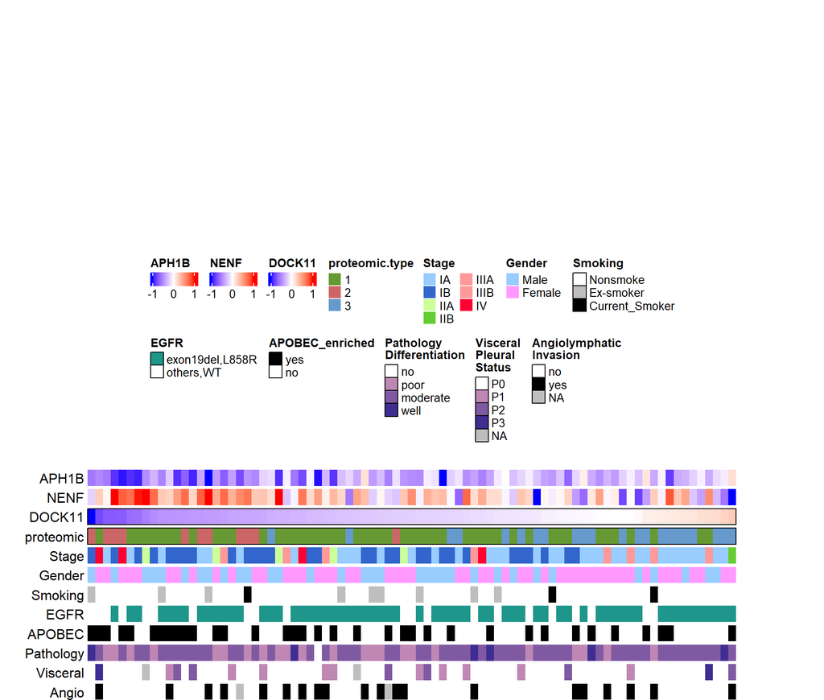

```r
# if (!requireNamespace("BiocManager", quietly=TRUE))
#     install.packages("BiocManager")
# BiocManager::install("ComplexHeatmap")
library(ComplexHeatmap)
library(tidyverse)
library(circlize)
library(RColorBrewer)

gene_score_data <- merge(gene_score_data, information, by = 'ID')
DOCK11.df <- gene_score_data[order(gene_score_data$DOCK11),]

col_fun = colorRamp2(c(-1, 0, 1), c("blue", "white", "red"))
DOCK11_hm = HeatmapAnnotation(APH1B = DOCK11.df$APH1B,
                            NENF = DOCK11.df$NENF,
                            DOCK11 = DOCK11.df$DOCK11,
                            proteomic = DOCK11.df$`proteome_k3 (out of k4)`,
                            Stage = DOCK11.df$Stage,
                            Gender = DOCK11.df$Gender.x,
                            Smoking = DOCK11.df$`Smoking Status`,
                            EGFR = DOCK11.df$EGFR_Status,
                            APOBEC = DOCK11.df$APOBEC_Enriched,
                            Pathology = DOCK11.df$PathologyDifferentiation,
                            Visceral = DOCK11.df$VisceralPleuralStatus,
                            Angio = DOCK11.df$AngiolymphaticInvasion,
                            col = list(DOCK11 = col_fun,
                                       NENF = col_fun,
                                       APH1B = col_fun,
                                       proteomic = c('1'='#669933','2'='#CC6666','3'='#6699CC'),
                                       Stage = c('IA' = '#99CCFF','IB' = '#3366CC','IIA'='#CCFF99',
                                                 'IIB'='#66CC33','IIIA'='#FF9999','IIIB'='#FF9999','IV'='#FF0033'),
                                       Gender = c('Male' = '#99CCFF', 'Female' = '#FF99FF'),
                                       Smoking = c('Nonsmoke' = 'white', 'Ex-smoker' = 'grey', 'Current_Smoker' = 'black'),
                                       EGFR = c('exon19del' = '#1F968BFF','L858R' = '#1F968BFF','L858R.exon19del' = '#1F968BFF',
                                                'others' = 'white','WT' = 'white'),
                                       APOBEC = c('yes' = 'black','no'='white'),
                                       Pathology = c('no'='white','poor'='#BF87B3','moderate'='#7F5AA2','well'='#3F2D91'),
                                       Visceral = c('P0'='white','P1'='#BF87B3','P2'='#7F5AA2','P3'='#3F2D91','NA'='grey'),
                                       Angio = c('no' = 'white','yes'='black', 'NA'='grey')),
                            annotation_legend_param = list(
                              APH1B = list(title = "APH1B", at = c(-1, 0, 1))
                            ),
                            show_annotation_name = TRUE,
                            show_legend = TRUE,
                            annotation_name_side = 'left',
                            border = c(DOCK11 = TRUE, proteomic = TRUE),
                            gap = unit(1, "mm"),
                            width = unit(20, "cm"))


# make legends
lgd1 = Legend(col_fun = col_fun, title = "APH1B", at = c(-1,0,1), direction = "horizontal")
lgd2 = Legend(col_fun = col_fun, title = "NENF", at = c(-1,0,1), direction = "horizontal")
lgd3 = Legend(col_fun = col_fun, title = "DOCK11", at = c(-1,0,1), direction = "horizontal")
lgd4 = Legend(labels = c('1','2','3'), legend_gp = gpar(fill = c('1'='#669933','2'='#CC6666','3'='#6699CC')), title = "proteomic.type")
lgd5 = Legend(labels = c('IA','IB','IIA','IIB','IIIA','IIIB','IV'), legend_gp = gpar(fill = c('IA' = '#99CCFF','IB' = '#3366CC','IIA'='#CCFF99','IIB'='#66CC33','IIIA'='#FF9999','IIIB'='#FF9999','IV'='#FF0033')), title = "Stage", ncol = 2)
lgd6 = Legend(labels = c('Male','Female'), legend_gp = gpar(fill = c('Male' = '#99CCFF', 'Female' = '#FF99FF')), title = "Gender")
lgd7 = Legend(labels = c('Nonsmoke','Ex-smoker','Current_Smoker'), legend_gp = gpar(fill = c('Nonsmoke' = 'white', 'Ex-smoker' = 'grey', 'Current_Smoker' = 'black')), title = "Smoking", border = 'black')
lgd8 = Legend(labels = c('exon19del,L858R','others,WT'), legend_gp = gpar(fill = c('exon19del,L858R' = '#1F968BFF', 'others,WT' = 'white')), title = "EGFR", border = 'black')
lgd9 = Legend(labels = c('yes','no'), legend_gp = gpar(fill = c('yes' = 'black','no'='white')), title = "APOBEC_enriched", border = 'black')
lgd10 = Legend(labels = c('no','poor','moderate','well'), legend_gp = gpar(fill = c('no'='white','poor'='#BF87B3','moderate'='#7F5AA2','well'='#3F2D91')), title = "Pathology\nDifferentiation", border = 'black')
lgd11 = Legend(labels = c('P0','P1','P2','P3','NA'), legend_gp = gpar(fill = c('P0'='white','P1'='#BF87B3','P2'='#7F5AA2','P3'='#3F2D91','NA'='grey')), title = "Visceral\nPleural\nStatus", border = 'black')
lgd12 = Legend(labels = c('no','yes','NA'), legend_gp = gpar(fill = c('no' = 'white','yes'='black', 'NA'='grey')), title = "Angiolymphatic\nInvasion", border = 'black')


# combine legends
pd = packLegend(lgd1, lgd2, lgd3, lgd4, lgd5, lgd6, lgd7, lgd8, lgd9, lgd10, lgd11, lgd12, direction = "horizontal", max_width = unit(20, "cm"))


draw(pd)
draw(DOCK11_hm)
```

```r
# boxplot for p-value
library(ggpubr)
my_comparisons <- list( c("1", "2"), c("2", "3"), c("1", "3") )
p1 <- gene_score_data %>%
  filter(Stage %in% c('IA','IB')) %>%
  ggplot(aes(`proteome_k3 (out of k4)`, DOCK11)) +
  geom_boxplot(aes(fill = `proteome_k3 (out of k4)`)) +
  scale_fill_manual(values =  c("#669933", "#CC6666","#6699CC")) +
  geom_jitter(alpha = 0.3) +
  stat_compare_means(comparisons = my_comparisons, label.y = c(0.2, 0.3, 0.4), label = "p.signif", size = 5) +
  xlab("proteomic type") +
  ggtitle("Calculation of P-value of\nDOCK11 among Proteomic types") +
  theme_bw()

p2 <- gene_score_data %>%
  filter(Stage %in% c('IA','IB')) %>%
  ggplot(aes(`proteome_k3 (out of k4)`, NENF)) +
  geom_boxplot(aes(fill = `proteome_k3 (out of k4)`)) +
  scale_fill_manual(values =  c("#669933", "#CC6666","#6699CC")) +
  geom_jitter(alpha = 0.3) +
  stat_compare_means(comparisons = my_comparisons, label.y = c(1.2, 1.3, 1.5), label = "p.signif", size = 5) +
  xlab("proteomic type") +
  ggtitle("Calculation of P-value of\nNENF among Proteomic types") +
  theme_bw()

p3 <- gene_score_data %>%
  filter(Stage %in% c('IA','IB')) %>%
  ggplot(aes(`proteome_k3 (out of k4)`, APH1B)) +
  geom_boxplot(aes(fill = `proteome_k3 (out of k4)`)) +
  scale_fill_manual(values =  c("#669933", "#CC6666","#6699CC")) +
  geom_jitter(alpha = 0.3) +
  stat_compare_means(comparisons = my_comparisons, label.y = c(0.1, 0.2, 0.3), label = "p.signif", size = 5) +
  xlab("proteomic type") +
  ggtitle("Calculation of P-value of\nAPH1B among Proteomic types") +
  theme_bw()
```

The purpose of distinguishing Proteomic type 1 is to identify clinical application by dividing patients in IA and IB stages into late-like stages. Therefore, let’s predict the proteomic type for patients at that stages.

The dots below 33.3% are subtype2, the dots above 66.6% are subtype3, and the rests are classified as subtype1, so `proteome_predicted` is designated using `mutate`, and the dotplot is drawn again based on this. As a result of dividing the number of patients whose original proteomic type matches the predicted type by the total number of patients, it can be seen that the accuracy was about 64.62%.

```r
original.proteome <- gene_score_data %>%
  filter(Stage %in% c('IA','IB')) %>%
  select(ID, DOCK11, `proteome_k3 (out of k4)`)

tert = quantile(gene_score_data$DOCK11, c(1:2/3))  # calculate tertile of log2T/N of DOCK11


original <- original.proteome %>%
  ggplot(aes(`proteome_k3 (out of k4)`, DOCK11, fill = `proteome_k3 (out of k4)`)) +
  geom_dotplot(binaxis = 'y', stackdir = 'center') +
  scale_fill_manual(values =  c("#669933", "#CC6666","#6699CC")) +
  geom_hline(yintercept = tert, linetype = 'dashed', color = 'red', size = 1.3) + # vline with 33% and 66%.
  geom_text(aes(1.5, -0.35, label = "33.3%"), col = 'red') +
  geom_text(aes(1.5, -0.06, label = "66.6%"), col = 'red') +
  xlab("proteomic type") +
  ggtitle("Original Proteomic Type\n of IA & IB Patients") +
  labs(fill = "proteomic type") +
  theme_bw()
```

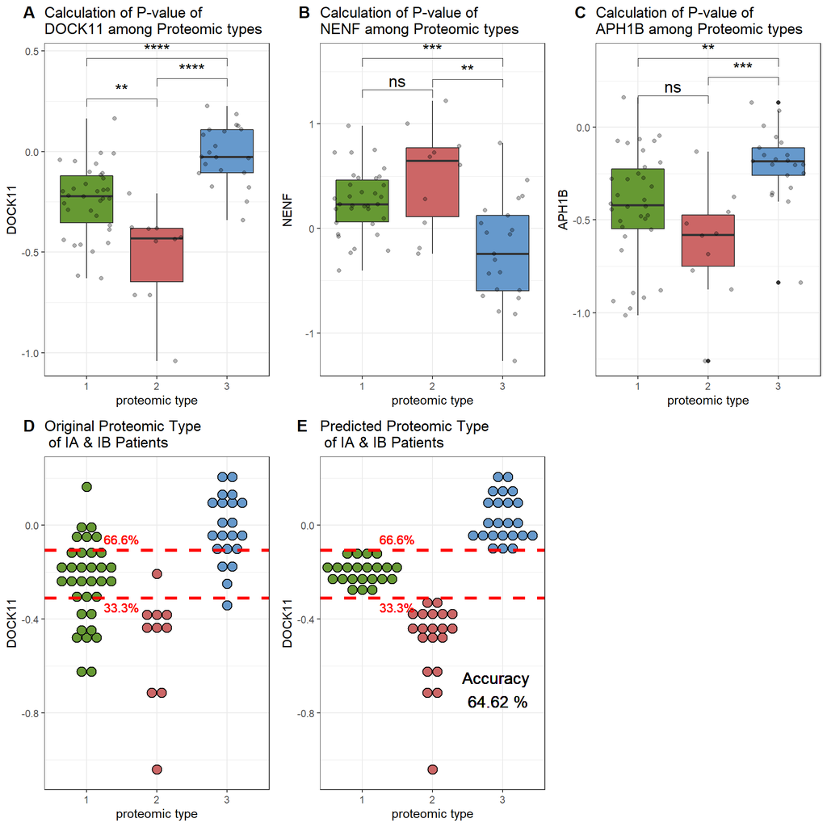

```r
predicted.proteome <- gene_score_data %>%
  filter(Stage %in% c('IA','IB')) %>%
  select(ID, DOCK11, `proteome_k3 (out of k4)`) %>%
  mutate(proteome_predicted = case_when(
    DOCK11 < tert[1] ~ '2',
    DOCK11 > tert[2] ~ '3',
    TRUE ~ '1'
  )) %>%
  mutate(same = ifelse(`proteome_k3 (out of k4)` == proteome_predicted, 'yes', 'no'))


accuracy <- round(sum(predicted.proteome$same == 'yes') / nrow(predicted.proteome), digits = 4) * 100





predicted <- predicted.proteome%>%
  ggplot(aes(proteome_predicted, DOCK11, fill = proteome_predicted)) +
  geom_dotplot(binaxis = 'y', stackdir = 'center') +
  scale_fill_manual(values =  c("#669933", "#CC6666","#6699CC")) +
  geom_hline(yintercept = tert, linetype = 'dashed', color = 'red', size = 1.3) + # label vline with 33% and 66%.
  geom_text(aes(1.5, -0.35, label = "33.3%"), col = 'red') +
  geom_text(aes(1.5, -0.06, label = "66.6%"), col = 'red') +
  geom_text(aes(2.9, -0.7, label = paste("Accuracy\n", accuracy, "%")), size = 5) +
  xlab("proteomic type") +
  ggtitle("Predicted Proteomic Type\n of IA & IB Patients") +
  theme_bw()


# combine plots
library(cowplot)
combined.plot <- plot_grid(
  p1 + theme(legend.position="none"),
  p2 + theme(legend.position="none"),
  p3 + theme(legend.position="none"),
  original + theme(legend.position="none"),
  predicted + theme(legend.position="none"),
  align = 'vh',
  labels = c("A", "B", "C", "D", "E"),
  hjust = -2,
  nrow = 2)
combined.plot
```

(In figure A, B, and C, p-values are represented by using symbol(*). ‘ns’ means p-value > 0.05, ‘**’ means p-value < 0.01, ‘***’ means p-value < 0.001, and ‘****’ means p-value < 0.0001.)

# 3. Conclusion

In our paper, several clinical implications were identified by dividing the proteomic type into three according to the protein pattern, and dividing IA and IB patients into late-like stages. As a result of predicting the proteomic type through DOCK11, a DEP that was identified through the stromal scores and the immune scores, I could predict proteomic types with about 64.62% accuracy. This was the result of using values of only one protein and simply dividing the group by tertile.

DOCK11 used for prediction facilitates filopodia formation through the activation of CDC42. And filopodia stimulate cell migration in many cell types and increased filopodia density has been described in cancer. Several proteins implicated in filopodia formation are relevant for cancer progression, but I suggests that DOCK11 is not only likely to be associated with cancer progression, but also possible to distinguish proteomic types.

Through a follow-up study of finding a larger number of significant proteins and dividing the DOCK11 value more precisely than simply calculated tertile values, a few DEPs may be combined to determine the proteomic type and perform prognostic diagnosis, instead of measuring the expression amount of the entire protein and analyzing the expression pattern to determine the patient’s proteomic type and use it as prognostic factor.

# 4. Development through peer reviews

I received four major comments through peer reviews.

1. Revision of the code of the first chunk
2. Minor corrections in plots and texts
3. Suggestion 1: Increasing accuracy of prediction using all three DEPs
4. Suggestion 2: Drawing plots of IA and IB patients, respectively

## 4.1. Revision of the code of the first chunk

As mentioned above, I made a fatal mistake in the first chunk. It was found through the peer review that there was a mistake in the code `gene_score_data[2:7631] <- lapply(gene_score_data, as.numeric)` and that proper data can be used only when it is corrected to `gene_score_data[2:7631] <- lapply(gene_score_data[2:7631], as.numeric)`. This mistake resulted in data being pushed back one by one, and when the proper code was used, DEPs were DOCK11, NENF, and APH1B. The previously thought that FGD3 had a significant result were the significant result of DOCK11. Through this, I revised all FGD3 to DOCK11, and learned that I should not trust my code unconditionally and should check the derived results.

## 4.2. Minor corrections in plots and texts

Most reviews have suggested corrections of font size in plots, additional information in texts, and method of expression in plots. The list below is what I modified.

- Add a description of stromal score and immune score to the introduction.
- Add a description of DOCK11 protein.
- Change the x-axis title of some plot from ‘proteome_k3’ to ‘proteomic type’.
- Mark the value of p-value as a symbol (*) instead of numbers to aid in intuitive understanding of figure A, B, and C.
- Decrease the size of letters such as ‘33.3%’, ‘66.6%’, and ‘accuracy’ in figure D and E.
- Write down the reason why [2:7631] is on the first chunk.

## 4.3. Suggestion 1: Increasing accuracy of prediction using all three DEPs

In the midterm assignment, proteomic types were predicted using only DOCK11, and 64.62% accuracy could be obtained. A peer review suggested using all three DEPs for higher accuracy. In fact, as can be confirmed through figure B and C, NENF and APH1B also showed significant differences between ‘proteome 1’ group and ‘proteome 3’ group, ‘proteome 2’ group and ‘proteome 3’ group. Therefore, higher accuracy could be obtained if all DEPs as well as DOCK11 are properly utilized.

```r
# calculation of tertiles of all DEPs
tert.DOCK11 = quantile(gene_score_data$DOCK11, c(1:2/3))
tert.NENF = quantile(gene_score_data$NENF, c(1:2/3))
tert.APH1B = quantile(gene_score_data$APH1B, c(1:2/3))


# calculation of accuracy of DOCK11-predicted
predicted.proteome.DOCK11 <- gene_score_data %>%
  filter(Stage %in% c('IA','IB')) %>%
  select(ID, DOCK11, `proteome_k3 (out of k4)`) %>%
  mutate(proteome_predicted = case_when(
    DOCK11 < tert.DOCK11[1] ~ '2',
    DOCK11 > tert.DOCK11[2] ~ '3',
    TRUE ~ '1'
  )) %>%
  mutate(same = ifelse(`proteome_k3 (out of k4)` == proteome_predicted, 'yes', 'no'))

accuracy_DOCK11 <- round(sum(predicted.proteome.DOCK11$same == 'yes') / nrow(predicted.proteome.DOCK11), digits = 4) * 100


# calculation of accuracy of NENF-predicted
predicted.proteome.NENF <- gene_score_data %>%
  filter(Stage %in% c('IA','IB')) %>%
  select(ID, NENF, `proteome_k3 (out of k4)`) %>%
  mutate(proteome_predicted = case_when(
    NENF < tert.NENF[1] ~ '3',
    NENF > tert.NENF[2] ~ '2',
    TRUE ~ '1'
  )) %>%
  mutate(same = ifelse(`proteome_k3 (out of k4)` == proteome_predicted, 'yes', 'no'))

accuracy_NENF <- round(sum(predicted.proteome.NENF$same == 'yes') / nrow(predicted.proteome.NENF), digits = 4) * 100


# calculation of accuracy of APH1B-predicted
predicted.proteome.APH1B <- gene_score_data %>%
  filter(Stage %in% c('IA','IB')) %>%
  select(ID, APH1B, `proteome_k3 (out of k4)`) %>%
  mutate(proteome_predicted = case_when(
    APH1B < tert.APH1B[1] ~ '2',
    APH1B > tert.APH1B[2] ~ '3',
    TRUE ~ '1'
  )) %>%
  mutate(same = ifelse(`proteome_k3 (out of k4)` == proteome_predicted, 'yes', 'no'))

accuracy_APH1B <- round(sum(predicted.proteome.APH1B$same == 'yes') / nrow(predicted.proteome.APH1B), digits = 4) * 100


# calculation of accuracy by considering all DEPs
predicted.proteome.plus <- gene_score_data %>%
  filter(Stage %in% c('IA','IB')) %>%
  select(ID, DOCK11, NENF, APH1B, `proteome_k3 (out of k4)`) %>%
  mutate(proteome_predicted_DOCK11 = case_when(
    DOCK11 < tert.DOCK11[1] ~ '2',
    DOCK11 > tert.DOCK11[2] ~ '3',
    TRUE ~ '1'
  )) %>%
  mutate(proteome_predicted_NENF = case_when(
    NENF < tert.NENF[1] ~ '3',
    NENF > tert.NENF[2] ~ '2',
    TRUE ~ '1'
  )) %>%
  mutate(proteome_predicted_APH1B = case_when(
    APH1B < tert.APH1B[1] ~ '2',
    APH1B > tert.APH1B[2] ~ '3',
    TRUE ~ '1'
  ))

predicted.proteome.plus[6:8] <- lapply(predicted.proteome.plus[6:8], as.numeric) # change character into numeric


# an equation reflecting the accuracy of each DEP
predicted.proteome.final <- predicted.proteome.plus %>%
  mutate(proteome_predicted_avg = ((accuracy_DOCK11 + 0.5*(100-accuracy_NENF) + 0.5*(100-accuracy_APH1B))*proteome_predicted_DOCK11 + (accuracy_NENF + 0.5*(100-accuracy_DOCK11) + 0.5*(100-accuracy_APH1B))*proteome_predicted_NENF + (accuracy_APH1B + 0.5*(100-accuracy_NENF) + 0.5*(100-accuracy_DOCK11))*proteome_predicted_APH1B) / 300
  ) %>% # try to consider each accuracy (another version)
  mutate(proteome_predicted_final = round(proteome_predicted_avg)) %>%
  mutate(same = ifelse(`proteome_k3 (out of k4)` == proteome_predicted_final, 'yes', 'no'))

accuracy_final <- round(sum(predicted.proteome.final$same == 'yes') / nrow(predicted.proteome.final), digits = 4) * 100
paste(accuracy_final, '%')
```

```
## [1] "38.46 %"
```

Accuracy of NENF and APH1B was measured in the same way that the proteomic type was predicted using DOCK11 log2T/N value in 2.3. Referring to figure B, values below 33.3% are proteomic type 3, values above 66.6% are proteomic type 2, and the rests are classified as proteomic type 1. As a result, interestingly, both the accuracy calculated using only NENF and the accuracy calculated using only APH1B were 53.85%.

An equation reflecting the accuracy of each DEP was established to determine the final proteomic type and calculate the accuracy, but a lower value of 38.46% was derived. The use of simply calculated tertile and the wrong equation which isn’t exquisite are considered to be the cause of the failure of more precise prediction.

## 4.4. Suggestion 2: Drawing plots of IA and IB patients, respectively.

The reason for distinguishing protein in the paper (Chen et al., 2020) was to distinguish the late-like stage from IA and IB stage. Therefore, in the previous plot (figure D and E), patients in stages IA and IB were filtered, and prediction accuracy was calculated.

However, several peer reviews have suggested separating patients in IA and IB to draw plots and calculate accuracy of prediction. This was a proposal based on the difference between IA and IA-late-like, IB and IB-late-like. Thus, patients in stage IA and IB were filtered, respectively, and original proteomic type and predicted proteomic type plots were drawn and the prediction accuracy was calculated.

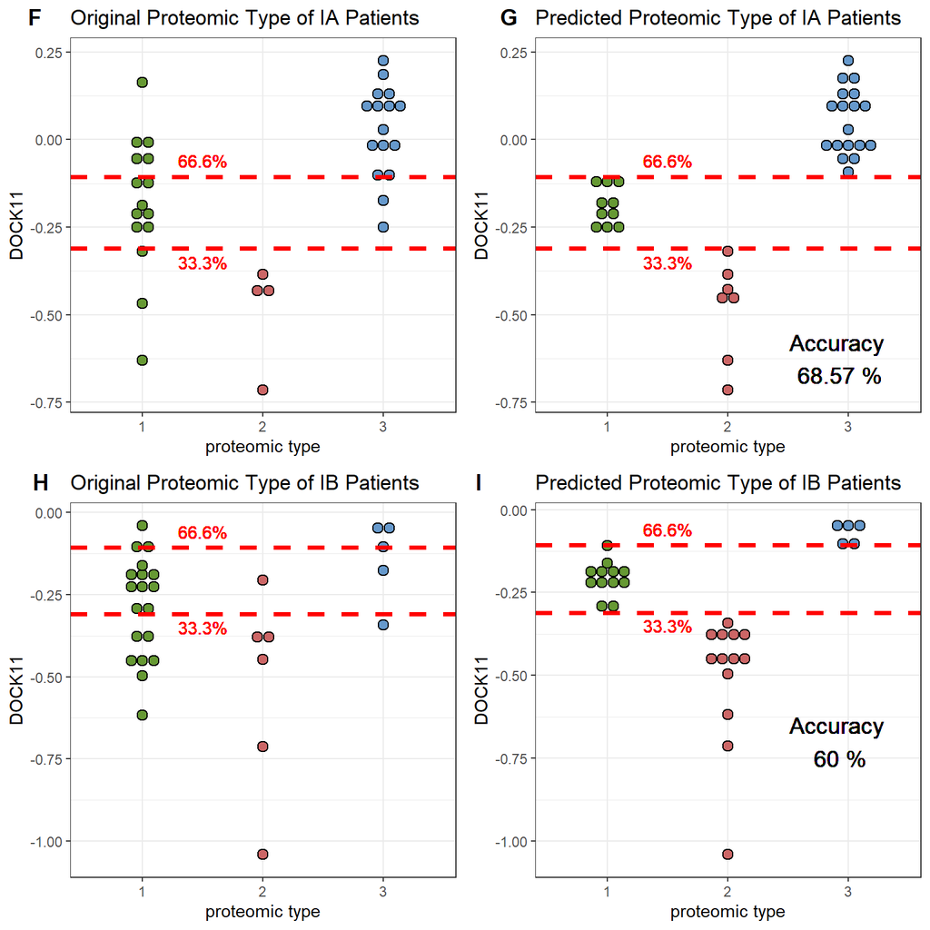

```r
# data of IA patients
original.proteome.IA <- gene_score_data %>%
  filter(Stage == 'IA') %>%
  select(ID, Stage, DOCK11, `proteome_k3 (out of k4)`)

tert = quantile(gene_score_data$DOCK11, c(1:2/3))  # calculate tertile of log2T/N of DOCK11


# original proteomic type of IA patients
original.IA <- original.proteome.IA %>%
  ggplot(aes(`proteome_k3 (out of k4)`, DOCK11, fill = `proteome_k3 (out of k4)`)) +
  geom_dotplot(binaxis = 'y', stackdir = 'center') +
  scale_fill_manual(values =  c("#669933", "#CC6666","#6699CC")) +
  geom_hline(yintercept = tert, linetype = 'dashed', color = 'red', size = 1.3) + # I want to label vline with 33% and 66%.
  geom_text(aes(1.5, -0.35, label = "33.3%"), col = 'red') +
  geom_text(aes(1.5, -0.06, label = "66.6%"), col = 'red') +
  xlab("proteomic type") +
  ggtitle("Original Proteomic Type of IA Patients") +
  labs(fill = "proteomic type") +
  theme_bw()


# predicted data of IA patients
predicted.proteome.IA <- original.proteome.IA %>%
  mutate(proteome_predicted = case_when(
    DOCK11 < tert[1] ~ '2',
    DOCK11 > tert[2] ~ '3',
    TRUE ~ '1'
  )) %>%
  mutate(same = ifelse(`proteome_k3 (out of k4)` == proteome_predicted, 'yes', 'no'))


accuracy.IA <- round(sum(predicted.proteome.IA$same == 'yes') / nrow(predicted.proteome.IA), digits = 4) * 100


# predicted proteomic type of IA patients
predicted.IA <- predicted.proteome.IA%>%
  ggplot(aes(proteome_predicted, DOCK11, fill = proteome_predicted)) +
  geom_dotplot(binaxis = 'y', stackdir = 'center') +
  scale_fill_manual(values =  c("#669933", "#CC6666","#6699CC")) +
  geom_hline(yintercept = tert, linetype = 'dashed', color = 'red', size = 1.3) + # I want to label vline with 33% and 66%.
  geom_text(aes(1.5, -0.35, label = "33.3%"), col = 'red') +
  geom_text(aes(1.5, -0.06, label = "66.6%"), col = 'red') +
  geom_text(aes(2.9, -0.625, label = paste("Accuracy\n", accuracy.IA, "%")), size = 5) +
  xlab("proteomic type") +
  ggtitle("Predicted Proteomic Type of IA Patients") +
  theme_bw()




# data of IB patients
original.proteome.IB <- gene_score_data %>%
  filter(Stage %in% 'IB') %>%
  select(ID, Stage, DOCK11, `proteome_k3 (out of k4)`)

tert = quantile(gene_score_data$DOCK11, c(1:2/3))  # calculate tertile of log2T/N of DOCK11


# original proteomic type of IB patients
original.IB <- original.proteome.IB %>%
  ggplot(aes(`proteome_k3 (out of k4)`, DOCK11, fill = `proteome_k3 (out of k4)`)) +
  geom_dotplot(binaxis = 'y', stackdir = 'center') +
  scale_fill_manual(values =  c("#669933", "#CC6666","#6699CC")) +
  geom_hline(yintercept = tert, linetype = 'dashed', color = 'red', size = 1.3) + # I want to label vline with 33% and 66%.
  geom_text(aes(1.5, -0.35, label = "33.3%"), col = 'red') +
  geom_text(aes(1.5, -0.06, label = "66.6%"), col = 'red') +
  xlab("proteomic type") +
  ggtitle("Original Proteomic Type of IB Patients") +
  labs(fill = "proteomic type") +
  theme_bw()


# predicted data of IB patients
predicted.proteome.IB <- original.proteome.IB %>%
  mutate(proteome_predicted = case_when(
    DOCK11 < tert[1] ~ '2',
    DOCK11 > tert[2] ~ '3',
    TRUE ~ '1'
  )) %>%
  mutate(same = ifelse(`proteome_k3 (out of k4)` == proteome_predicted, 'yes', 'no'))


accuracy.IB <- round(sum(predicted.proteome.IB$same == 'yes') / nrow(predicted.proteome.IB), digits = 4) * 100


# predicted proteomic type of IB patients
predicted.IB <- predicted.proteome.IB%>%
  ggplot(aes(proteome_predicted, DOCK11, fill = proteome_predicted)) +
  geom_dotplot(binaxis = 'y', stackdir = 'center') +
  scale_fill_manual(values =  c("#669933", "#CC6666","#6699CC")) +
  geom_hline(yintercept = tert, linetype = 'dashed', color = 'red', size = 1.3) + # I want to label vline with 33% and 66%.
  geom_text(aes(1.5, -0.35, label = "33.3%"), col = 'red') +
  geom_text(aes(1.5, -0.06, label = "66.6%"), col = 'red') +
  geom_text(aes(2.9, -0.7, label = paste("Accuracy\n", accuracy.IB, "%")), size = 5) +
  xlab("proteomic type") +
  ggtitle("Predicted Proteomic Type of IB Patients") +
  theme_bw()


# combine plots
combined.plot2 <- plot_grid(
  original.IA + theme(legend.position="none"),
  predicted.IA + theme(legend.position="none"),
  original.IB + theme(legend.position="none"),
  predicted.IB + theme(legend.position="none"),
  align = 'vh',
  labels = c("F", "G", "H", "I"),
  hjust = -2,
  nrow = 2)
combined.plot2
```